# PPCA0026 - Tarefa de Casa 1: Introdução ao Quarto com R

- Show All Code
- Hide All Code
- View Source

Author

Denard Soares

Published

June 5, 2025

## Introdução

Bem-vindo(a) à primeira tarefa de casa da disciplina PPCA0026!

**Objetivos desta tarefa:**

1. Familiarizar-se com a criação de documentos `.qmd` (Quarto Markdown).
2. Aprender a integrar texto narrativo, blocos de código R e a saída desses blocos (incluindo gráficos e tabelas) em um único arquivo HTML auto-contido.
3. Praticar a criação de visualizações de dados básicas com `ggplot2` e manipulação de dados elementar com `dplyr`, baseando-se nos exemplos da Semana 1, Parte 2 e no Capítulo 1 do livro “R para Ciência de Dados” (R4DS).

**Referência Principal para Quarto:**

- Capítulo 28 do R4DS (tradução para o português): [Quarto - R para Ciência de Dados](https://pt.r4ds.hadley.nz/quarto.html)

**Instruções Gerais:**

- Substitua `"Seu Nome Aqui"` no cabeçalho YAML pelo seu nome completo.
- Complete as seções de código R onde indicado.
- Escreva suas interpretações e respostas textuais onde solicitado.
- Após completar o arquivo `.qmd`, renderize-o para HTML. Certifique-se de que a opção `embed-resources: true` está no cabeçalho YAML para que o HTML seja auto-contido.
- Envie **ambos** os arquivos: o `.qmd` e o `.html` resultante.

## 1. Configuração Inicial

Este primeiro bloco de código carrega os pacotes necessários. A opção de chunk `include: false` significa que o código será executado, mas nem o código nem sua saída aparecerão no documento HTML final. Isso é útil para códigos de configuração.

Agora que o `tidyverse` está carregado, podemos acessar o conjunto de dados `mpg`.

```r
# Vamos dar uma olhada nas primeiras linhas do dataset mpg
# e na sua estrutura para nos familiarizarmos.
head(mpg)
```

```
# A tibble: 6 × 11
  manufacturer model displ  year   cyl trans      drv     cty   hwy fl    class
  <chr>        <chr> <dbl> <int> <int> <chr>      <chr> <int> <int> <chr> <chr>
1 audi         a4      1.8  1999     4 auto(l5)   f        18    29 p     compa…
2 audi         a4      1.8  1999     4 manual(m5) f        21    29 p     compa…
3 audi         a4      2    2008     4 manual(m6) f        20    31 p     compa…
4 audi         a4      2    2008     4 auto(av)   f        21    30 p     compa…
5 audi         a4      2.8  1999     6 auto(l5)   f        16    26 p     compa…
6 audi         a4      2.8  1999     6 manual(m5) f        18    26 p     compa…
```

```r
str(mpg)
```

```
tibble [234 × 11] (S3: tbl_df/tbl/data.frame)
 $ manufacturer: chr [1:234] "audi" "audi" "audi" "audi" ...
 $ model       : chr [1:234] "a4" "a4" "a4" "a4" ...
 $ displ       : num [1:234] 1.8 1.8 2 2 2.8 2.8 3.1 1.8 1.8 2 ...
 $ year        : int [1:234] 1999 1999 2008 2008 1999 1999 2008 1999 1999 2008 ...
 $ cyl         : int [1:234] 4 4 4 4 6 6 6 4 4 4 ...
 $ trans       : chr [1:234] "auto(l5)" "manual(m5)" "manual(m6)" "auto(av)" ...
 $ drv         : chr [1:234] "f" "f" "f" "f" ...
 $ cty         : int [1:234] 18 21 20 21 16 18 18 18 16 20 ...
 $ hwy         : int [1:234] 29 29 31 30 26 26 27 26 25 28 ...
 $ fl          : chr [1:234] "p" "p" "p" "p" ...
 $ class       : chr [1:234] "compact" "compact" "compact" "compact" ...
```

```r
?mpg # Para ver a documentação do dataset
```

## 2. Primeiro Gráfico: Consumo na Estrada vs. Cilindrada

Nesta seção, você criará um gráfico de dispersão para explorar a relação entre a cilindrada do motor (`displ`) e o consumo de combustível na estrada (`hwy`), usando o dataset `mpg`.

**Tarefa:**

1. Crie um gráfico de dispersão (`geom_point`) com `displ` no eixo x e `hwy` no eixo y.
2. Mapeie a variável `class` (tipo de carro) para a estética `color` dos pontos.
3. Adicione um título informativo ao gráfico e rótulos apropriados para os eixos x e y (em português).
4. Escreva uma breve interpretação do gráfico na seção de texto abaixo do bloco de código.

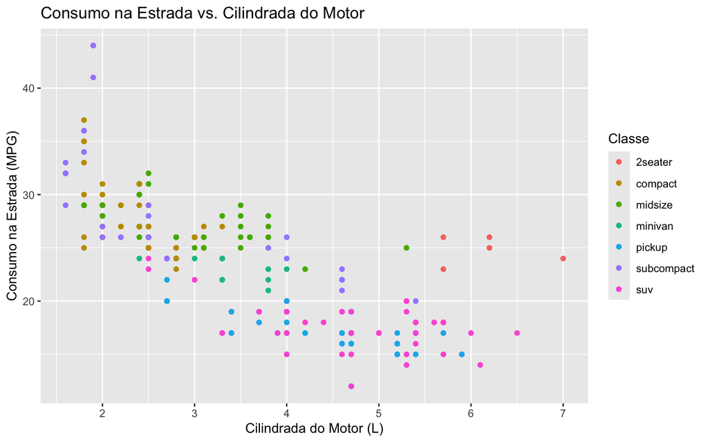

Gráfico de dispersão: Consumo na estrada (hwy) vs. Cilindrada do motor (displ), colorido por classe do veículo.

```r
ggplot(data = mpg, aes(x = displ, y = hwy, color = class)) +
  geom_point() +
  labs(title = "Consumo na Estrada vs. Cilindrada do Motor",
       x = "Cilindrada do Motor (L)",
       y = "Consumo na Estrada (MPG)",
       color = "Classe")
```

**Interpretação do Gráfico de Dispersão:**

*Escreva sua interpretação aqui. O que você observa sobre a relação entre `displ` e `hwy`? Como a `class` do veículo parece influenciar essa relação?* Observa-se uma clara tendência inversa entre a cilindrada do motor (`displ`) e o consumo na estrada (`hwy`): veículos com motores maiores (maior `displ`) tendem a ter menor eficiência de combustível na estrada (menor `hwy`). A classe do veículo (`class`), indicada pelas cores, modula essa relação. Carros compactos e subcompactos (geralmente em tons mais claros ou específicos no gráfico) concentram-se na área de baixa cilindrada e alta eficiência. Em contraste, SUVs e picapes (outras cores) dominam a região de alta cilindrada e baixa eficiência. Veículos de duas portas (`2seater`), embora variados em cilindrada, podem apresentar eficiência relativamente alta. Isso sugere que, embora a cilindrada seja um fator importante, características associadas à classe do veículo, como peso e aerodinâmica, também desempenham um papel crucial na determinação do consumo rodoviário.

## 3. Adicionando uma Linha de Suavização

Vamos aprimorar o gráfico anterior adicionando uma linha de suavização para visualizar melhor a tendência geral.

**Tarefa:**

1. Copie o código do gráfico anterior.
2. Adicione uma camada `geom_smooth()` ao gráfico. Mantenha o mapeamento de cores por `class` para a linha de suavização também, se desejar (ou crie uma linha de suavização geral).
3. Observe a linha (ou linhas) de suavização. O que ela(s) sugere(m)?

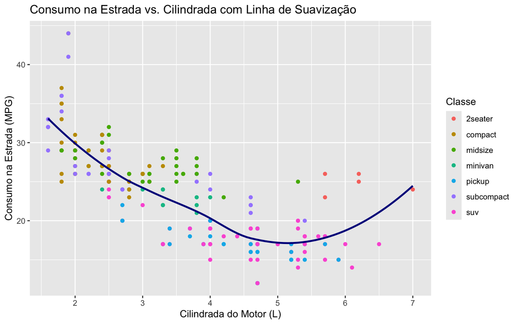

```r
ggplot(data = mpg, aes(x = displ, y = hwy)) + # Mapeamento base sem cor
  geom_point(aes(color = class)) + # Cor mapeada apenas nos pontos
  geom_smooth(method = "loess", se = FALSE, color = "darkblue") + # Linha de suavização geral (loess), sem intervalo de confiança
  labs(title = "Consumo na Estrada vs. Cilindrada com Linha de Suavização",
       x = "Cilindrada do Motor (L)",
       y = "Consumo na Estrada (MPG)",
       color = "Classe")
```

**Interpretação da Linha de Suavização:**